# Assignment 7

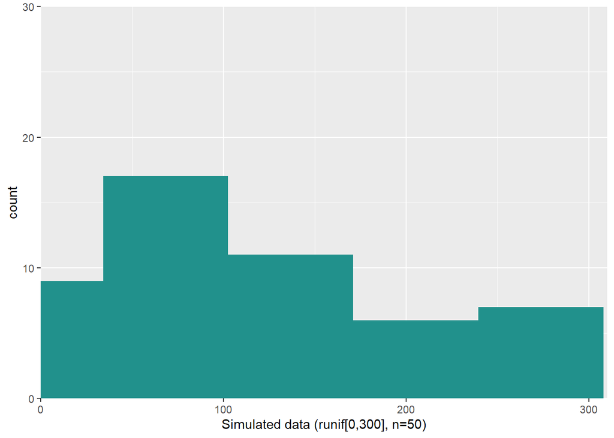

```r
simrunifplot <- simrunif %>%
  ggplot(aes(x=value)) +
  coord_cartesian(expand = FALSE, ylim=c(0,30), xlim=c(0,310)) +
  geom_histogram(fill="#21918c", bins=5) +
  xlab("Simulated data (runif[0,300], n=50)")

simrunifplot
```

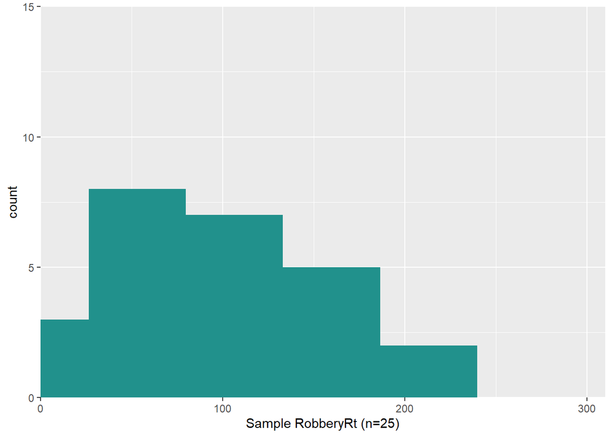

```r
sampleplot <- StatesDataRdm25 %>%
  ggplot(aes(x=RobberyRt)) +
  coord_cartesian(expand = FALSE, ylim=c(0,15), xlim=c(0,310)) +
  geom_histogram(fill="#21918c", bins=5) +
  xlab("Sample RobberyRt (n=25)")

sampleplot
```

8. Assuming you loaded the “patchwork” package earlier, it is trivially easy to combine these plots into a single plot - just add the two objects together and patchwork will do its magic automatically!
   1. Insert an R chunk.
   2. Type `simrunifplot + sampleplot` and hit run!

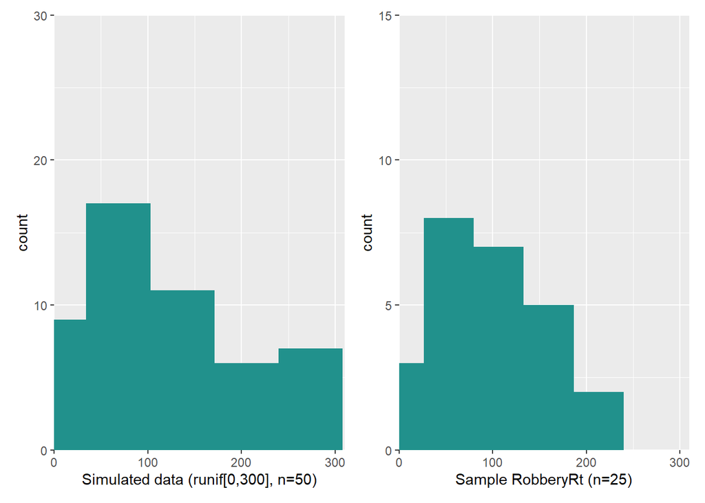

```r
simrunifplot + sampleplot
```

- We can also customize a patchwork plot in various ways, such as placing an empty space between plot objects by adding (`+`) a `plot_spacer()`, specifying the plot layout by adding a `plot_layout()`, or including a title by adding `plot_annotation(title="My Title")`. We can also use `/` to indicate which plot(s) we want on top and which we want on bottom. For example, click the code box below to see two different ways to generate the same combined plot using patchwork:

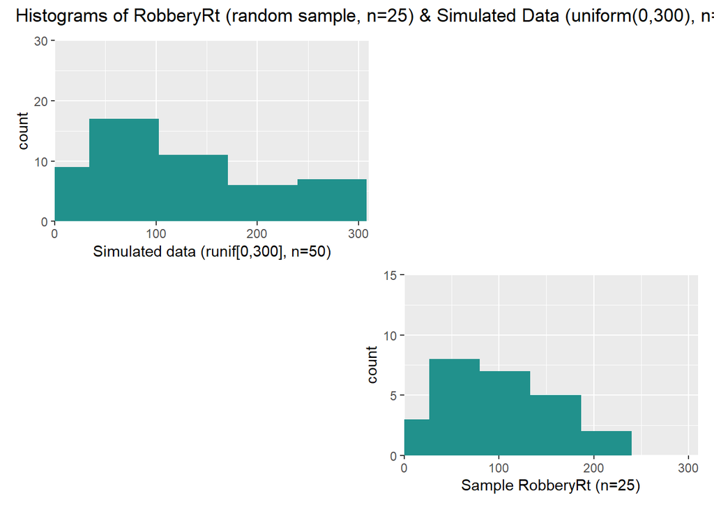

```r
# Illustrate patchwork with plot spacers, formatting, and adding a title
(simrunifplot + plot_spacer()) /  (plot_spacer() + sampleplot) +
  plot_annotation(
    title = 'Histograms of RobberyRt (random sample, n=25) & Simulated Data (uniform(0,300), n=50)')
```

```r
# Alternative way to generate same plot
# simrunifplot + plot_spacer() + plot_spacer() + sampleplot +
#   plot_layout(ncol = 2) +
#   plot_annotation(
#     title = 'Histograms of RobberyRt (random sample, n=25) & Simulated Data (uniform(0,300), n=50)')
```

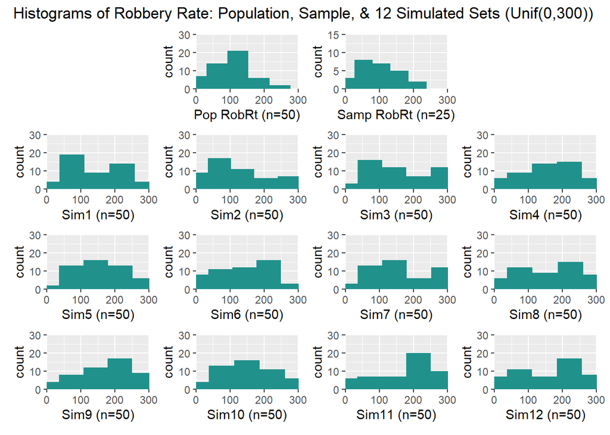

```r
# Replicate 12 simulated samples from uniform(0,300) distribution
set.seed(1234)
simrunif12robrt <- replicate(n = 12,
          expr = runif(n = 50,
                       min = 0,
                       max = 300),
          simplify = TRUE) %>%
  as_tibble()

# Alt code to simulate n=50 RobberyRt values from gamma(2,60) distribution
# set.seed(1234)
# simrgam12robrt <- replicate(n = 12,
#           expr = rgamma(n = 50,
#                        shape = 2,
#                        scale = 60),
#           simplify = TRUE) %>%
#   as_tibble()

#create function to quickly plot custom histograms
  #function inputs: data; variable to plot; number of bins for geom_histogram; y-axis max; x-axis label
funhist = function(dat,var,numbins,ymax,x_label){
  dat %>%
    ggplot(aes(x={{var}})) +
    geom_histogram(fill="#21918c", bins=numbins) +
    coord_cartesian(expand = FALSE, ylim=c(0,ymax), xlim=c(0,300)) +
    xlab(x_label)
  }

histpop <- funhist(StatesData, RobberyRt, 5, 30, "Pop RobRt (n=50)")
histsamp <- funhist(StatesDataRdm25, RobberyRt, 5, 15, "Samp RobRt (n=25)")
histv1runif <- funhist(simrunif12robrt, V1, 5, 30, "Sim1 (n=50)")
histv2runif <- funhist(simrunif12robrt, V2, 5, 30, "Sim2 (n=50)")
histv3runif <- funhist(simrunif12robrt, V3, 5, 30, "Sim3 (n=50)")
histv4runif <- funhist(simrunif12robrt, V4, 5, 30, "Sim4 (n=50)")
histv5runif <- funhist(simrunif12robrt, V5, 5, 30, "Sim5 (n=50)")
histv6runif <- funhist(simrunif12robrt, V6, 5, 30, "Sim6 (n=50)")
histv7runif <- funhist(simrunif12robrt, V7, 5, 30, "Sim7 (n=50)")
histv8runif <- funhist(simrunif12robrt, V8, 5, 30, "Sim8 (n=50)")
histv9runif <- funhist(simrunif12robrt, V9, 5, 30, "Sim9 (n=50)")
histv10runif <- funhist(simrunif12robrt, V10, 5, 30, "Sim10 (n=50)")
histv11runif <- funhist(simrunif12robrt, V11, 5, 30, "Sim11 (n=50)")
histv12runif <- funhist(simrunif12robrt, V12, 5, 30, "Sim12 (n=50)")

plot_spacer() + histpop + histsamp + plot_spacer() +
  histv1runif + histv2runif + histv3runif +
  histv4runif + histv5runif + histv6runif +
  histv7runif + histv8runif + histv9runif +
  histv10runif + histv11runif + histv12runif +
        plot_layout(ncol = 4) +
  plot_annotation(
    title = 'Histograms of Robbery Rate: Population, Sample, & 12 Simulated Sets (Unif(0,300))' )
```

### Part 5 (Assignment 7.5)

#### Goal: Estimate Confidence Intervals around ‘RobberyRt’ Sample Mean

After our detour into data simulation from probability distributions, we hope that “sampling variability” makes a little more sense to you now. Understanding sampling variability is essential to truly comprehending confidence intervals. Interval estimates are one way that we attempt to quantify and communicate the uncertainty caused by sampling variability in our statistical estimates of population parameters. After all, if our random samples from a population do not vary at all (imagine sampling from a population of identical units), then we would not have any uncertainty in our estimates and would not need to generate intervals to try to capture the true population parameters!

1. Create second-level header titled: “Part 5 (Assignment 7.5)”. Then, create a third-level header titled: “95% Confidence Intervals for ‘RobberyRt’ Sample Mean
2. Revisit the formulas for estimating confidence intervals presented in your book. In order to estimate a CI around a sample mean, we will need to know:
   1. the sample mean, of course
   2. the sample standard deviation
   3. the sample size
   4. the appropriate *z* (large sample) or *t* (small sample) critical value associated with our desired confidence level (e.g., 90%, 95%, 99%).
3. At this point, you know various ways to determine the sample mean and sd in R. We will use base R functions `mean(data$var)` and `sd(data$var)` and assign these sample values for “RobberyRt” to objects. Remember, you will do this again for “AssaultRt” at the end of this section. We will also assign the sample size (`n <- 25`) to the object `n`; since our sample stays the same, we can use this object for this section and the next section.
- **Note:** Remember, the `StatesDataRdm25` data object contains only the 25 randomly selected states. We are practicing interval estimation of population parameters from a random sample, so do not use the full dataset (`StatesData`)!

*Sample Mean of RobberyRt (n=25 states)*

```r
sampmeanRobRt <- mean(StatesDataRdm25$RobberyRt)
sampmeanRobRt
```

```
## [1] 99.424
```

*Sample SD of RobberyRt (n=25 states)*

```r
sampsdRobRt <- sd(StatesDataRdm25$RobberyRt)
sampsdRobRt
```

```
## [1] 57.07451
```

*Sample Size*

```r
n <- 25
n
```

```
## [1] 25
```

4. Now that we have assigned our mean, standard deviation, and sample size as value objects, we need to identify the proper critical value before we can estimate a confidence interval around our sample mean.
   1. Recall, since we are estimating from a small sample, we use the formula that invokes the *t* distribution because it has fatter tails than the *z* distribution and, hence, generates somewhat more conservative estimates for small, noisy samples.
   2. You can find critical *t* values in Table B.3 at the back of your book. Or, we can use R to identify our critical *t* value. Either way, you will need to know the significance level (e.g., alpha = .05 or .01) and the degrees of freedom (for this, *df* = n-1 = 25-1 = 24).
      - *Note:* The book’s SPSS exercise 3.b asks you to calculate the standard error and 95% confidence interval for “AssaultRt” in our random sample, which you will do later. Since we are illustrating how to calculate a CI around the mean of “RobberyRt” at the same confidence level (95%) and with the same sample size (n=25), we will be using the same *t* critical value.
   3. For our interval estimate, we would need the *t* critical value for a two-tailed test with alpha=0.05 and *df*=24. According to the table in our book, that *t* value is 2.064.
   4. Instead of using the table in your book, you can generate this same *t* critical value in R using the `qt()` function by typing: `tcrit <- qt(p = .05/2, df = n-1, lower.tail = FALSE)`. Then, type `tcrit` to output the value and check to make sure it is the same (t=2.064)! (*Note:* We also rounded the output to show the book’s value and the R value is the same.)
      - `qt()` generates specific “quantiles” from the *t* distribution. With a two-tailed 95% CI, we want to specify 0.05 (i.e., 5%) of samples to fall outside in the tails or “critical region” of the *t* distribution.
      - Since we are generating a two-tailed confidence interval, we split 0.05 in half - 0.025% is in the left tail and 0.025% is in the right tail.
   - Wait, why did we divide our alpha level by `2` to get that same *t* critical value from the book? We know this can be confusing. Try to remember that, for a two-tailed confidence interval, you need to divide the alpha level by two.
     - Recall, the alpha level essentially represents the proportion of the standard curve that is specified in the tails of the distribution as the critical region. Since we are generating a two-tailed 95% CI, we want the critical region to cover 5% in the tails of the distribution to ensure 95% CI coverage probability.
     - Essentially, for a 95% CI, we will add 2.5% margin of error below the sample mean and 2.5% margin of error above the sample mean, for 5% total margin of error. So, the 5% critical region is split across both tails of the *t* distribution, which translates to 2.5% or 0.025 (0.05/2 = 0.025) in each of the the left and right tails, respectively.

*t critical value for two-tailed test, alpha=.05, df=24*

```r
# Determine t critical value for alpha = .05 (to estimate 95% CI)
  # For two-tailed test, divide alpha level by two (for both tails)!
tcrit <- qt(p = .05/2, df = n-1, lower.tail = FALSE)
tcrit
```

```
## [1] 2.063899
```

*t critical value, rounded to 3 digits to compare with book*

```r
round(tcrit, 3)
```

```
## [1] 2.064
```

*Sample Std Error of Mean of RobberyRt & 95% margin of error*

```r
sampseRobRt <- (sampsdRobRt/sqrt(n))
sampseRobRt
```

```
## [1] 11.4149
```

```r
marg95RobRt <- tcrit*sampseRobRt
marg95RobRt
```

```
## [1] 23.5592
```

```r
#Alternative method for calculating 95% margin of error in R using qt()
# qt(0.975,df=n-1)*sampsdRobRt/sqrt(n)
```

6. With the 95% margin of error of the mean estimated and assigned to an object, we can simply subtract it from the sample mean to calculate the lower 95% CI limit, then add it to the sample mean to calculate the upper 95% CI limit. Together, these make up the 95% confidence interval estimate around the sample mean of “RobberyRt”.
   1. Insert an R chunk.
   2. Type `RobRt95CIlow <- sampmeanRobRt - marg95RobRt`. Hit enter and type `RobRt95CIhi <- sampmeanRobRt + marg95RobRt`. Type each of the object names on subsequent lines to print their output values and run your code.
   3. *Note:* To learn more about calculating CI using R, you might check out [here](https://www.statology.org/confidence-interval-in-r/) and [here](https://www.statology.org/confidence-interval-mean/).

*Lower bound of 95% confidence interval around sample mean*

```r
RobRt95CIlow <- sampmeanRobRt - marg95RobRt
RobRt95CIlow
```

```
## [1] 75.8648
```

*Upper bound of 95% confidence interval around sample mean*

```r
RobRt95CIhi <- sampmeanRobRt + marg95RobRt
RobRt95CIhi
```

```
## [1] 122.9832
```

*95% CI Estimate around Sample Mean of RobberyRt*

```r
cat("[",RobRt95CIlow,",",RobRt95CIhi,"]")
```

```
## [ 75.8648 , 122.9832 ]
```

- You just calculated 95% confidence interval estimates around the sample mean of RobberyRt from our 25 randomly selected states!
  - As you can see, our lower bound is 75.86 and our upper bound is 122.98.
  - This means our 95% CI around the sample mean of “RobberyRt” is [75.86, 122.98].
7. Now, for the question you all have been waiting to ask: Did our sample-specific 95% parameter-catching interval estimate happen to catch the true population mean this time? Well, since we actually have the population data, we can check! Use R to check the population mean of “RobberyRt” in the `StatesData`, then compare it to our 95% CI estimate around the sample mean.

*Population Mean of RobberyRt*

```r
mean(StatesData$RobberyRt)
```

```
## [1] 104.584
```

- Yes, the population mean (104.58) was captured in our sample’s 95% confidence interval estimate [75.86, 122.98].
  - In other words, our random sample was one of the 95% of samples we might have drawn that would be expected to generate 95% confidence intervals that capture the true population mean.
  - Of course, we only know this because we have the population data. Remember, usually we would not know whether our interval estimates contain the true population parameter because we typically estimate population parameters from sample data without the luxury of having access to population data. In the typical case, we must settle for being confident that such interval estimates will capture the true population parameters *most of the time* when we follow appropriate measurement, sampling, and estimation methods.
  - Finally, it should not be surprising that our 95% CI captures the true population value, since it is intended to do just that in 95 out 100 repeated sampling trials. However, note that our 95% CI estimates are not very precise - they cover a pretty wide range of plausible state robbery rate values. With small samples and heterogeneous populations, the only way to ensure our CIs provide 95% frequency coverage probability is by generating wide, imprecise interval estimates!
8. You should now know everything you need to generate a confidence interval around a sample mean on your own in R. Follow the procedures illustrated above to estimate a two-tailed 95% CI for the sample mean of “AssaultRt” and answer questions 3.b through 3.d from Chapter 7 SPSS Exercises.
   - Create new headings and subheadings as appropriate, and describe what you are doing throughout in the text portion of your RMD document.
   - *Note:* You might want to read through the next section of this assignment before attempting to interpret the confidence intervals that you estimate!

### Interpreting Confidence Intervals

#### Goal: Understand how to appropriately interpret a frequentist confidence interval

Now that you have estimated a 95% confidence interval around the sample mean of “RobberyRt”, we want to discuss how to appropriately interpret these intervals before we estimating any more of them.

You may recall us mentioning earlier that frequentist confidence intervals are routinely misinterpreted. So, how do we appropriately interpret them? Well, we are glad you asked! Here is an appropriate interpretation of the 95% CI that we just estimated:

**CORRECT INTERPRETATION:** We are 95% confident that the true population mean robbery rate is between 75.86 and 122.98. By 95% confident, we mean that over the long run (and assuming our research design and statistical model are sound), the same procedures would result in estimates and confidence intervals that capture the true population mean in 95% of trials.

In addition to knowing the correct interpretation, it is worth recognizing a few common misinterpretations. Though the distinctions at times appear to be quite subtle, each of the following is technically a misinterpretation:

- **Inaccurate:** We are 95% certain that the true population proportion falls between 75.86 and 122.98.
- This sounds correct, so why is it considered a misinterpretation? Well, it is because “95% confidence” has a very specific meaning in frequentist statistics. Recall, we are not 95% confident in - or 95% certain of - *the specific interval* that we estimated. Rather, our level of confidence is in the *method* or *procedures* used to estimate the interval and not in the specific interval itself.
- **Inaccurate:** There is a 95% chance that the true population proportion falls between 75.86 and 122.98.
- Again, this sounds correct, and under a very specific (frequentist) interpretation of “chance” or “probability” it arguably might be considered correct. However, it is listed as a misinterpretation for the same reasons we explained in the example above.
- In fact, the true population parameter either *is* or *is not* in the frequentist confidence interval we estimated, so it either has a 0% or 100% chance of falling in the specific interval we estimated. Of course, we usually do not know whether our interval caught the true population parameter because we rarely have data from the entire population. So, again, the 95% confidence level refers to our confidence in the 95% frequency coverage probability of interval estimates (hypothetically) generated over the long run across repeated trials and not to the chances that the specific interval we estimated captures the true population parameter.
- **Inaccurate:** In 100 repeated trials, 95% of new samples will have a population mean that falls between 75.86 and 122.98.
- This is just a slightly confused deviation from the truth. Here, the interpretation seems to get the long run frequency coverage notion of probability correct. However, this interpretation again is too focused on the specific interval (i.e., “between 75.86 and 122.98”) we estimated with our single sample rather than recognizing that different samples would generate different point and interval estimates.
- Moreover, what does it mean to say that “95% of new samples will have a population mean…”? Remember, *sample* statistics like the mean, standard deviation, and confidence intervals will likely vary across samples due to sampling variability; however, the true population parameter (e.g., mean; sd) is the same regardless of the specific characteristics of any given sample.
- **Inaccurate:** *If we replicated our study, we would get the same results 95% of the time.*
- Remember that we are estimating intervals to quantify the uncertainty in estimation due to sampling variability and to minimize inference errors by estimating intervals that have a high probability of long run frequency coverage. Like we saw in our simulations above, random samples drawn from a population often differ from each other and from the population - if we understand that such sampling variability is typical, then we should also expect the point and interval estimates to vary across random samples as well.
- Exceptions to this rule occur when we draw random samples from homogeneous populations (e.g., if all states had the same robbery rate) or when we select very large random samples - because we would expect little to no sampling variability in these situations. Still, even in these circumstances, we would not interpret CIs in this way.
- So, in fact, *most* of the random samples of n=25 states that we could have drawn from the population of all 50 states would have generated *different results* - that is, different “RobberyRt” means, standard deviations, and 95% CIs!

We illustrate sampling variability - and CI variability - in the figure below, in which we plotted the mean and 95% CI from our sample (sample #1 at the bottom) along with means and 95% CIs from eight other samples of n=25 states each randomly drawn from “StatesData” using a different random starting seed. As you can see, all nine (ours + 8 new samples) generated different point estimates (dots = sample means) and interval estimates (error bars = 95% CIs around sample means). In this particular case, all nine of the estimated 95% confidence intervals managed to capture the true population parameter (vertical line = population mean of “RobberyRt”).

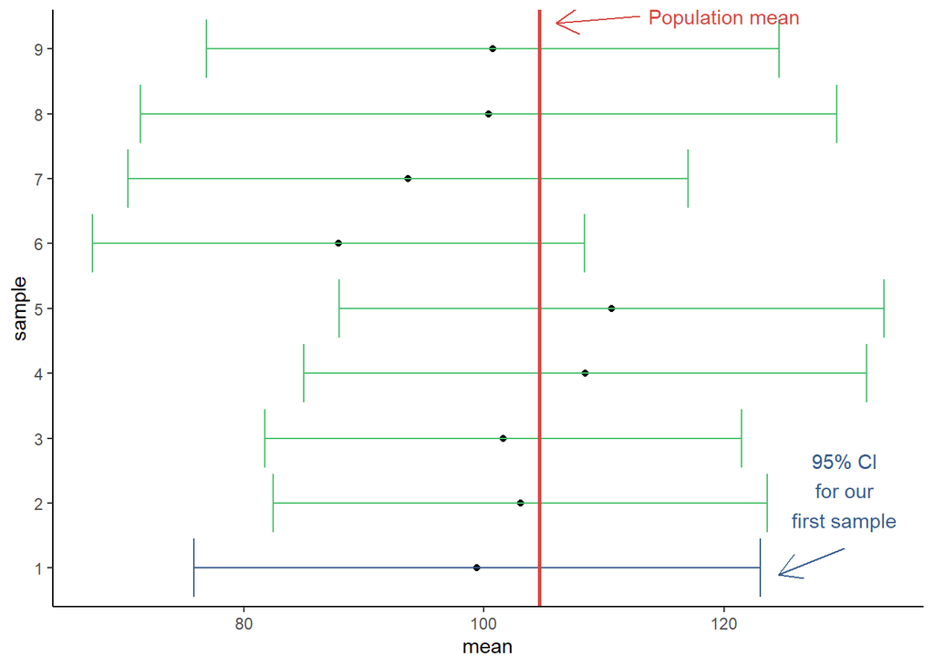

```r
#generate three more random samples of n=25 states from StatesData
set.seed(1)
samp2 <- StatesData %>% sample_n(25, replace = FALSE)
set.seed(21)
samp3 <- StatesData %>% sample_n(25, replace = FALSE)
set.seed(31)
samp4 <- StatesData %>% sample_n(25, replace = FALSE)
set.seed(41)
samp5 <- StatesData %>% sample_n(25, replace = FALSE)
set.seed(51)
samp6 <- StatesData %>% sample_n(25, replace = FALSE)
set.seed(61)
samp7 <- StatesData %>% sample_n(25, replace = FALSE)
set.seed(71)
samp8 <- StatesData %>% sample_n(25, replace = FALSE)
set.seed(81)
samp9 <- StatesData %>% sample_n(25, replace = FALSE)

#create function to calculate stnd error of mean for 95% CI
fun95se = function(dat){
  (qt(0.975,df=24)*sd({{dat}}$RobberyRt)/sqrt(25))
  }

#create tibble with sample, mean(RobberyRt), and se(mean)
statesamps <- tribble(
  ~sample, ~mean,  ~marg95,
  "1", mean(StatesDataRdm25$RobberyRt),  fun95se(StatesDataRdm25),
  "2", mean(samp2$RobberyRt),  fun95se(samp2),
  "3", mean(samp3$RobberyRt), fun95se(samp3),
  "4", mean(samp4$RobberyRt), fun95se(samp4),
  "5", mean(samp5$RobberyRt), fun95se(samp5),
  "6", mean(samp6$RobberyRt), fun95se(samp6),
  "7", mean(samp7$RobberyRt), fun95se(samp7),
  "8", mean(samp8$RobberyRt), fun95se(samp8),
  "9", mean(samp9$RobberyRt), fun95se(samp9)
)

statesamps <- statesamps %>%
  mutate(
    CI95low = mean - marg95,
    CI95hi = mean + marg95
  )

ggplot(statesamps, aes(mean, sample)) +
  geom_point() +
  geom_errorbar(aes(xmin = CI95low, xmax = CI95hi, color=sample)) +
  geom_vline(xintercept = mean(StatesData$RobberyRt, linetype="dashed"),
                color = "#d44842", size=1) +
  geom_segment(aes(x = 130, y = 1.3, xend = 124.5, yend = .9),
                  arrow = arrow(length = unit(0.5, "cm")), color="#365c8d") +
  annotate("text", x=130, y=2.2, label="95% CI\nfor our\nfirst sample", angle=0, color="#365c8d") +
  geom_segment(aes(x = 113, y = 9.5, xend = 106, yend = 9.4),
                  arrow = arrow(length = unit(0.5, "cm")), color="#d44842") +
  annotate("text", x=120, y=9.5, label="Population mean", angle=0, color="#d44842") +
  # scale_color_viridis_d() +
  scale_colour_manual(values=c('#365c8d','#4ac16d', '#4ac16d', '#4ac16d', '#4ac16d', '#4ac16d', '#4ac16d', '#4ac16d', '#4ac16d', '#4ac16d')) +
  theme_classic() +
  theme(legend.position = "none")
```

```r
#https://statisticsglobe.com/draw-plot-with-confidence-intervals-in-r
```

- *Note:* There are more efficient ways of generating a figure like this. For instance, we could have used `replicate()` to generate and assign numerous samples to a single combined data object or to a list of separate objects, then calculate our estimates and generate a plot from that single data object or list. (We will illustrate some more efficient approaches in the next assignment). Instead, we generated eight more samples and assigned them to separate data objects. We then created a single tibble containing the sample mean and standard error from each of our nine samples, calculated 95% upper and lower CI limits for each sample in our new tibble, and then plotted our means and 95% CIs from this tibble. Our hope is that you can more easily follow our logic with this explicit approach.
- Also, we wanted to show you how to plot means and confidence intervals using `ggplot() + geom_point() + geom_errorbars`, as well as illustrating how you can add other elements like a vertical line (`+ geom_vline()`), an arrow (`+ geom_segment`), or text (`+ annotate()`) elements to a `ggplot()` object. While we do not expect you to reproduce this plot, please do not let us thwart your ambitions!

### Part 6 (Assignment 7.6)

#### Goal: Estimate Confidence Intervals around ‘AssaultRt’ Sample Proportion

In the last part of this assignment, you will use what you have learned to answer SPSS exercise question 5, which asks you to estimate 95% and 99% CIs around the proportion of states with an assault rate (“AssaultRt”) higher than 200 assaults in 100k in our random sample of 25 states. We will illustrate the process by estimating a 90% CI around this same proportion.

On that topic, you may have noticed that your book only provides a formula for calculating a confidence interval around a sample proportion with large samples, and it does not have an equivalent formula for small samples. What gives? Well, it turns out that these types of interval estimates are pretty error-prone with small samples, and [neither *z* nor *t* distributions are really very useful for generating valid intervals around proportions with small samples](https://stats.stackexchange.com/questions/411699/why-we-don-t-make-use-of-the-t-distribution-for-constructing-a-confidence-interv). Yet, the book asks you to do this anyway, so we will plug our nose and move forward using the formula for large samples, which relies on the *z* distribution.

1. Create second-level header titled: “Part 6 (Assignment 7.6)”. Then, create a third-level header titled: “90% Confidence Interval for ‘AssaultRt’ Sample Proportion”
2. Referring to your book, you will find the formula for a confidence interval around a sample proportion requires the following inputs:
   1. the proportion (p) itself, of course
   2. the complement of the proportion (1-p)
   3. the sample size, which we already assigned to the object `n`
   4. the critical *z* value associated with your specified confidence level
3. Our first step is to determine what proportion (p) of states in our random sample have more than 200 assaults per 100k.
   1. You can use a frequency table and calculate or check the cumulative frequencies for this value. Or, you can use the `count()` function to answer this question directly in R. We show you how to do this in the code below.
   2. However you do it, you should get 16 out of 25 states, or p=0.64.
   3. Assign this proportion value to an R object.
      - In the code below, we assigned this value to an object named `pAstRtgt200`, which stands for “**p**roportion **As**saul**tRt** **g**reater **t**han **200**”.
      - You could just call it “p”; however, [for many reasons, we prefer to use more informative names](https://djnavarro.net/slides-project-structure/#5).

*Sample Proportion of States w/Assault Rate >200”*

```r
StatesDataRdm25 %>% count(AssaultRt > 200)
```

```
## # A tibble: 2 × 2
##   `AssaultRt > 200`     n
##   <lgl>             <int>
## 1 FALSE                 9
## 2 TRUE                 16
```

```r
pAstRtgt200 <- 0.64
pAstRtgt200
```

```
## [1] 0.64
```

4. Next, identify the critical *z* value associated with a 90% confidence level and assign to an object.
   1. Since we are using the large sample formula (I know, I know…), we will invoke `qnorm()` instead of `qt()`, which is a quantile function that we can use to identify critical values from the standard normal (*z*) rather than *t* distribution.
   2. For our example, we will use `qnorm()` to find the 90% CI (two-tailed), though you will be doing this again on your own to estimate 95% and 99% confidence intervals.
      - Though we want a 90% CI, notice that we specify `0.95` in our code instead.
      - Remember, these quantile functions are designed to provide one-sided (left-tailed *or* right-tailed) critical values. Since we want to estimate a two-tailed 90% CI, we need to assign 10% of the total *t* distribution as the critical region to ensure 90% CI coverage probability. This translates to a critical region containing 5% (10/2) in each of the left and right tails, respectively. Essentially, we will be adding 5% margin of error above and below the sample proportion. Subtracting 0.05 from 1.00 results in a 0.95 quantile specification (1.00 - 0.10/2 = 1.00 - 0.05 = 0.95), which will generate the appropriate *z* critical value for a two-tailed 90% confidence interval.
   3. Below, we use `qnorm()` to identify the appropriate *z* critical value for a 90% CI and assign it to an object named `zcrit`. That value is 1.64.
      - You can also find this value in the book’s Appendix Table B.1. That table is also set up to find one-tailed *z* critical values. So, for 90% CI coverage probability, our interval should cover 45% (0.45) of the *z* curve on each side, with 5% (0.05) of the curve specified as the critical region in each of the left and right tails. Therefore, we look in the body of the table for the *z* critical value associated with an area equaling 0.45 (0.4495) under the normal curve; this too will lead us to the value of 1.64.
      - *Note:* When you follow these procedures later to estimate two-tailed 95% and 99% confidence intervals around the “AssaultRt” sample proportion for question 5 of Chapter 7 SPSS Exercises, remember to identify the appropriate *z* critical values corresponding to the specified confidence level!

*Critical z value for two-tailed 90% CI*

```r
zcrit <- qnorm(0.95)
zcrit
```

```
## [1] 1.644854
```

5. We have what we need to estimate a confidence interval around our sample proportion. a. Recall, the formula for the standard error of the proportion (aka, the standard error of the sampling distribution of the proportion) is: se = sqrt(p(1-p)/n) and we multiply this by the critical *z* value to get the margin of error. b. In an R chunk, input our assigned objects into the formula by typing `marg90AstRtprop <- zcrit*sqrt(pAstRtgt200*(1-pAstRtgt200)/n)`. - This code estimates the margin of error for our 90% CI by multiplying our critical value by the square root of the proportion (.64) multiplied by its complement (or 1 - p) and divided by n. - The margin of error estimate is then assigned to a new value object called `marg90AstRtprop` (named differently so we do not confuse it with sample standard error for the mean of ‘RobberyRt’; the name refers to the sample **marg**in of error for **90**% CI around **As**saul**t** **R**a**t**e **prop**ortion).

*Standard error of Assault Rate proportion*

```r
marg90AstRtprop <- zcrit*sqrt(pAstRtgt200*(1-pAstRtgt200)/n)
marg90AstRtprop
```

```
## [1] 0.1579059
```

6. With the margin of error estimated and assigned to an object, we can now calculate the 90% confidence interval around our sample proportion. a. As we did in the previous section, we do this by simply subtracting from and adding to the sample proportion to calculate the lower and upper limits, respectively, for our 90% confidence interval around the “AssaultRt” sample proportion. b. We can do this by simply typing `AstProp90CIlow <- pAstRtgt200 - marg90AstRtprop` and `AstProp90CIhi <- pAstRtgt200 + marg90AstRtprop` to determine the 90% CI of the assault rate for our 25 states.

*90% CI lower limit for AssaultRt proportion*

```r
AstProp90CIlow <- pAstRtgt200 - marg90AstRtprop
AstProp90CIlow
```

```
## [1] 0.4820941
```

*90% CI upper limit for AssaultRt proportion*

```r
AstProp90CIhi <- pAstRtgt200 + marg90AstRtprop
AstProp90CIhi
```

```
## [1] 0.7979059
```

*90% CI Estimate around AssaultRt Sample Proportion*

```r
cat("[",AstProp90CIlow,",",AstProp90CIhi,"]")
```

```
## [ 0.4820941 , 0.7979059 ]
```

- Congratulations! You just calculated a 90% confidence interval estimate for the proportion of states with an assault rate greater than 200. - Our lower bound estimate is 0.48 and our upper bound estimate is 0.8. That means our 90% CI around the sample proportion is [0.48, 0.8]. - We can interpret this interval as follows: We are 90% confident that the true population proportion of states with assault rates greater than 200 is between 0.48 and 0.8. - By 90% confident, we mean that over the long run the same procedures would result in estimates and confidence intervals that capture the true population proportion in 90% of trials, assuming our research design and statistical model (including the large sample formula) are appropriate.

- Did our 90% parameter-catching interval estimate happen to catch the true population proportion this time? Once again, since we actually have the population data, we can check.

*Population Proportion of States w/Assault Rate >200*

```r
StatesData %>% count(AssaultRt > 200)
```

```
## # A tibble: 2 × 2
##   `AssaultRt > 200`     n
##   <lgl>             <int>
## 1 FALSE                21
## 2 TRUE                 29
```

```r
popAstRtprop <- 29/50
popAstRtprop
```

```
## [1] 0.58
```

- The population proportion is 0.58, which falls within the 90% confidence interval we estimated around our sample proportion (p=0.64, 90% CI=[0.48, 0.8]). It seems our random sample was one of the 90% of samples we might have drawn that would be expected to generate 90% confidence intervals that capture the true population proportion. Again, we only know this because we have the full population data - in most research situations, we do not have this luxury.

8. Follow the procedures illustrated above to estimate two-tailed 95% and 99% CIs around the “AssaultRt” sample proportion and answer question 5 from Chapter 7 SPSS Exercises.
   1. Create new headings and subheadings as appropriate, and describe what you are doing throughout in the text portion of your RMD document.
   2. Remember, with a different confidence level, your *z* critical value should change, which will then change your sample standard error, your margin of error (i.e., `marg90AstRtprop` value), and your lower and upper confidence limits (i.e., `AstProp90CIlow` and `AstProp90CIhi`).
   3. Also, recall that at higher confidence levels, we want to reduce inference errors by increasing the probability that our interval will contain the true population parameter. To do this, we are going to *widen* the interval, which will make us more confident that our parameter-catching net” will capture the true population parameter. This means that, if calculated correctly, your 95% and 99% CIs should be wider than the 90% CI we estimated above!
9. You should now have everything that you need to complete the questions in Canvas Assignment 7 that parallel those from the SPSS Exercises for Chapter 7. Complete the remainder of the questions in Assignment 7 in your RMD file and on Canvas.
   1. Keep the RMD file clean and easy to follow by using RMD level headings (e.g., denoted with ## or ###) separating R code chunks, organized by assignment questions.
   2. Write plain text after headings and before or after code chunks to explain what you are doing - such text will serve as useful reminders to you when working on later assignments!
   3. Upon completing the assignment, “knit” your final RMD file again and save the final knitted Word document to your “Assignments” folder as: **YEAR_MO_DY_LastName_K300Assign7**. Submit via Canvas in the relevant section (i.e., the last question) for Assignment 7.

### Assignment 7 Objective Checks

#### After completing assignment #7…

- are you able to select random sample from data without or with replacement using `dplyr::sample_n()`?
- do you know how to improve reproducibility of randomization tasks in R by setting the random number generator seed using `set.seed()`?
- are you able to select data with conditions using `dplyr::filter()` and `%in%` operator?
- do you know how to create a list or vector and assign to object, such as `listname <- c(item1, item2)`?
- do you recognize how one can simulate data from normal, truncated normal, or uniform probability distributions using `rnorm()`, `truncnorm::rtruncnorm()`, or `runif()`?
- recognize how one might write a custom function to repeatedly generate similar plots?
- are you able to combine multiple `ggplot()` plots into a single figure using “patchwork” package?
  - do you know how to customize the plot layout and add a title to a patchwork figure?
- do you understand how confidence intervals are used to quantify uncertainty caused by sampling variability?
  - are you able to estimate a two-tailed confidence interval around a sample mean or proportion in R and interpret it appropriately?
  - are you able to identify *t* or *z* critical values associated with a two-tailed confidence level using `qt()` or `qnorm()`?
  - do you know how to estimate the standard error of a sample mean or proportion in R?
  - do you understand how to properly interpret and avoid common misinterpretations of confidence intervals?
- do you recognize how one might plot means and confidence intervals using `ggplot() + geom_point() + geom_errorbars`?
- do you recognize how one might add elements like vertical lines (`+ geom_vline()`), arrows (`+ geom_segment`), or text (`+ annotate()`) elements to a `ggplot()` object?